# Finding Optimal #Topics

Class,

Quickly recapping our forays into Latent topic modeling (LTM), we’ve covered the most popular LTM method - LDA thus far. We’ve seen how to read LDA output, how to interpret topics etc.

However, recall that LDA (like k-means) requires the optimal #topics to be known a priori. What’re the odds given a random corpus, we’ll know a priori how many topics should be there?

### Intro to ldatuning

Many methods have been proposed over time on how to measure topic optimality. I present below an R package `ldatuning` that brings together some of the work on this subject under one roof. Behold.

```r
suppressPackageStartupMessages({
if (!require(ldatuning)) {install.packages("ldatuning")}
if (!require(topicmodels)) {install.packages("topicmodels")}

library("ldatuning")
library("topicmodels")
library(tidytext)
library(magrittr)
library(dplyr)
})
```

### Inbuilt Example

First, an inbuilt example from the package vignette given here: https://cran.r-project.org/web/packages/ldatuning/vignettes/topics.html

```r
data("AssociatedPress", package="topicmodels")
dtm <- AssociatedPress[1:10, ]
dim(dtm)
```

```
## [1]    10 10473
```

For illustration purposes, we’re taking just a small 10 document corpus from the inbuilt dataset `AssociatedPress` in the topicmodels package.

```r
system.time({
result <- FindTopicsNumber(
  dtm,
  topics = seq(from = 2, to = 15, by = 1),
  metrics = c("Griffiths2004", "CaoJuan2009", "Arun2010", "Deveaud2014"),
  method = "Gibbs",
  control = list(seed = 77),
  mc.cores = 2L,
  verbose = TRUE
)
})  # ~ 10 seconds
```

```
## fit models... done.
## calculate metrics:
##   Griffiths2004... done.
##   CaoJuan2009... done.
##   Arun2010... done.
##   Deveaud2014... done.
```

```
##    user  system elapsed
##    1.91    0.14   10.14
```

```r
result
```

| topics | Griffiths2004 | CaoJuan2009 | Arun2010 | Deveaud2014 |
| --- | --- | --- | --- | --- |
| 15 | -15297.82 | 0.5047240 | 15.92711 | 0.1362596 |
| 14 | -15338.24 | 0.4927860 | 15.36552 | 0.1406462 |
| 13 | -15319.82 | 0.4944709 | 15.80569 | 0.1504368 |
| 12 | -15326.94 | 0.4756351 | 15.81278 | 0.1594651 |
| 11 | -15293.55 | 0.4347111 | 15.23313 | 0.1770861 |
| 10 | -15291.00 | 0.3829542 | 14.93706 | 0.1969989 |
| 9 | -15303.87 | 0.3379840 | 14.71664 | 0.2181424 |
| 8 | -15256.30 | 0.3061726 | 14.78140 | 0.2435689 |
| 7 | -15259.80 | 0.2746812 | 14.82908 | 0.2746203 |
| 6 | -15251.04 | 0.2612029 | 15.28425 | 0.3101625 |

[output cut: 4 more lines]

4 metrics are computed and showcased of which 2 (CaoJuan2009 an Arun2010) are minimize metrics whereas the other 2 (Griffiths 2004, Deveaud 2014) are maximization ones.

How better to see whether or not a plurality of metrics supports a partiocular topic solution or not than by visualizing the same.

See below.

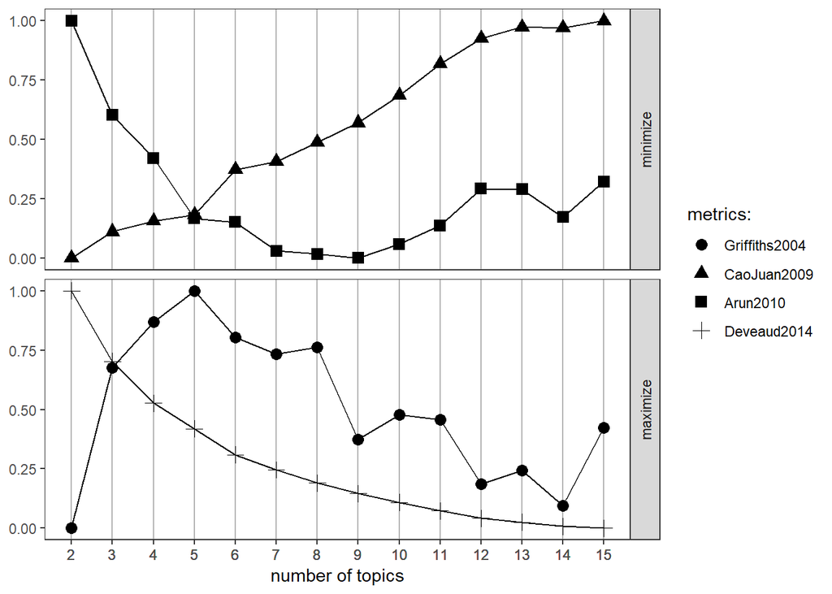

```r
FindTopicsNumber_plot(result)
```

Look at the figure above and guess what the optimal #topics, K, should be.

It is rare that all 4 metrics unanimously point to one optimal K. It is ideal but relatively uncommon. Often we have to judge based on whether a majority or at least a plurality of fit metrics point to a particular K.

### Replicating above on Nokia dataset

Time now to see if the above example which comes from the package vignette generalizes easily to other contexts and datasets.

And to do that we turn to our old favorite, the Nokia Lumia amazon dataset. See below.

```r
require(dplyr)
# get nokia dataset
nokia = readLines('https://github.com/sudhir-voleti/sample-data-sets/raw/master/text%20analysis%20data/amazon%20nokia%20lumia%20reviews.txt')

library(tidytext)
text  = nokia # %>% clean_text(alphanum=TRUE)
textdf = data.frame(docID=seq(1:length(text)), text = text, stringsAsFactors=FALSE)

system.time({
dtm1 = textdf %>%
     mutate(docID = row_number()) %>%    # row_number() is v useful.
     group_by(docID) %>%
     unnest_tokens(word, text) %>%
     anti_join(stop_words) %>%
     count(word, sort = TRUE) %>% ungroup() %>%
     cast_sparse(docID, word, n)

  # reorder dtm to sort rows by doc_num and cols by colsums
  dtm1 = dtm1[order(as.numeric(rownames(dtm1))),]
  b0 = apply(dtm1, 2, sum) %>% order(decreasing = TRUE)
  dtm1 = dtm1[, b0]
})
```

```
##    user  system elapsed
##    0.09    0.00    0.25
```

Am going to use standard tidytext functionality to build DTM and then run ldatuning.

```r
system.time({
result <- FindTopicsNumber(
  dtm1,
  topics = seq(from = 2, to = 20, by = 1),
  metrics = c("Griffiths2004", "CaoJuan2009", "Arun2010", "Deveaud2014"),
  method = "Gibbs",
  control = list(seed = 77),
  mc.cores = 2L,
  verbose = TRUE
)
})  # 28 seconds for nokia DS
```

```
## fit models... done.
## calculate metrics:
##   Griffiths2004... done.
##   CaoJuan2009... done.
##   Arun2010... done.
##   Deveaud2014... done.
```

```
##    user  system elapsed
##    0.85    0.10   24.85
```

```r
result
```

| topics | Griffiths2004 | CaoJuan2009 | Arun2010 | Deveaud2014 |
| --- | --- | --- | --- | --- |
| 20 | -36572.06 | 0.13820915 | 11.75881 | 0.9491786 |
| 19 | -36552.37 | 0.11370529 | 11.34268 | 0.9744331 |
| 18 | -36503.48 | 0.13700650 | 12.25249 | 0.9989241 |
| 17 | -36565.17 | 0.13497076 | 12.55200 | 1.0243674 |
| 16 | -36615.92 | 0.15262468 | 11.87622 | 1.0446048 |
| 15 | -36357.70 | 0.10765409 | 12.89131 | 1.1256526 |
| 14 | -36691.13 | 0.07718694 | 12.52619 | 1.1687629 |
| 13 | -36557.20 | 0.13265915 | 12.68580 | 1.1702016 |
| 12 | -36800.54 | 0.13880992 | 13.27084 | 1.1845978 |
| 11 | -36816.75 | 0.11739453 | 14.11713 | 1.2100046 |

[output cut: 9 more lines]

And now, finally, let’s see what the fit metrics look like and venture a guess on where the optimal K may lie.

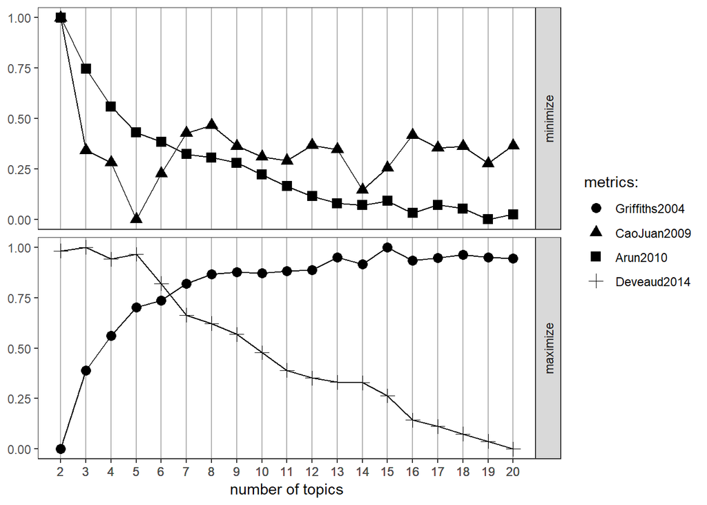

```r
  FindTopicsNumber_plot(result)
```

Chalo, back to the slides.

Sudhir